# Kaggle House Prices: Advanced Regression Techniques

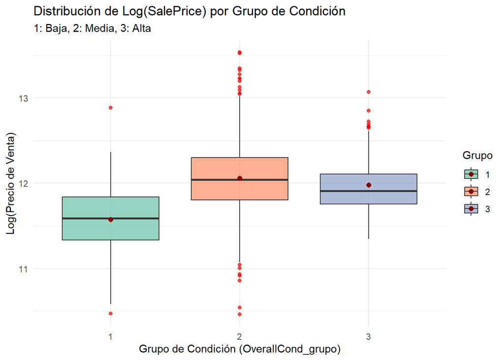

```r
ggplot(data=has,aes(x = as.factor(OverallCond_grupo), y = log(SalePrice), fill = as.factor(OverallCond_grupo))) +
  geom_boxplot(alpha = 0.7, outlier.color = "red") +
  stat_summary(fun = mean, geom = "point", shape = 20, size = 3, color = "darkred") +
  scale_fill_brewer(palette = "Set2") +
  labs(title = "Distribución de Log(SalePrice) por Grupo de Condición",
       subtitle = "1: Baja, 2: Media, 3: Alta",
       x = "Grupo de Condición (OverallCond_grupo)",
       y = "Log(Precio de Venta)",
       fill = "Grupo") +
  theme_minimal()
```

El análisis visual mediante boxplots confirma la baja asociación detectada por el coeficiente de Kendall, revelando una relación no monatóna entre la condición y el precio. Se observa que el Grupo 2 (Condición Media) presenta una mediana de ventas superior al Grupo 3 (Condición Alta), lo que sugiere que factores de depreciación por edad predominan sobre el estado de conservación en el segmento de gama alta. Dada esta inversión de la tendencia y la presencia de heterocedasticidad marcada, se descarta el uso de OverallCond_grupo como variable puramente ordinal, optándose por una codificación mediante variables dummy en la receta de tidymodels para capturar de forma independiente el intercepto de cada estrato. Para terminar las variables GarageCars y GarageArea se deja la que presenta mayor correlación, la cual es garageCars.

Análisis de Variables Categoricas Para reducir la dimensionalidad del espacio de predictores cualitativos, se realizó un análisis de varianza (ANOVA) de una vía sobre el logaritmo del precio. Se seleccionaron únicamente aquellas variables cuyo estadístico $F$ arrojó un p-valor inferior al umbral de significancia $\alpha = 0.05$, rechazando la hipótesis nula de que las medias de los grupos son equivalentes. Este filtrado asegura que la receta de preprocesamiento solo incluya factores con capacidad discriminante probada, optimizando la eficiencia computacional y reduciendo el riesgo de sobreajuste por ruido estocástico.

```r
# Vector para guardar resultados
variables_categoricas <- Entrenamiento_limpio %>%dplyr::select(where(is.character)) %>% colnames()
importantes_anova <- c()

for(cat_var in variables_categoricas){
  # Ajustamos un modelo lineal simple: Log(Precio) ~ Variable_Categorica
  modelo_anova <- aov(log(SalePrice) ~ get(cat_var), data = Entrenamiento_limpio)
  p_val <- summary(modelo_anova)[[1]][["Pr(>F)"]][1]

  # Guardamos solo las que tienen impacto real (p < 0.05)
  if(p_val < 0.05){
    importantes_anova <- c(importantes_anova, cat_var)
    cat("Variable:", cat_var, "| p-value:", p_val, " (Significativa)\n")
  }
}
```

```
## Variable: MSZoning | p-value: 0.00000000000000000000000000000000000000000000000000000000001021343  (Significativa)
## Variable: Street | p-value: 0.02837931  (Significativa)
## Variable: Alley | p-value: 0.000000001358108  (Significativa)
## Variable: LotShape | p-value: 0.00000000000000000000000000007856968  (Significativa)
## Variable: LandContour | p-value: 0.00000003086224  (Significativa)
## Variable: LotConfig | p-value: 0.0000006214575  (Significativa)
## Variable: Neighborhood | p-value: 0.000000000000000000000000000000000000000000000000000000000000…  (Significativa)
## Variable: Condition1 | p-value: 0.0000000001173444  (Significativa)
## Variable: Condition2 | p-value: 0.01382042  (Significativa)
## Variable: BldgType | p-value: 0.000000000003436794  (Significativa)
## Variable: HouseStyle | p-value: 0.000000000000000000000000000001636077  (Significativa)
## Variable: RoofStyle | p-value: 0.00000000000170574  (Significativa)
## Variable: RoofMatl | p-value: 0.0004504239  (Significativa)
## Variable: Exterior1st | p-value: 0.00000000000000000000000000000000000000000000000000001053128  (Significativa)
## Variable: Exterior2nd | p-value: 0.0000000000000000000000000000000000000000000000002429938  (Significativa)
## Variable: MasVnrType | p-value: 0.00000000000000000000000000000000000000000000000000000000000000001670061  (Significativa)
## Variable: ExterQual | p-value: 0.000000000000000000000000000000000000000000000000000000000000…  (Significativa)
## Variable: ExterCond | p-value: 0.00000000000006540305  (Significativa)
## Variable: Foundation | p-value: 0.000000000000000000000000000000000000000000000000000000000000000000000000000000000000000000000000000000000000001350671  (Significativa)
## Variable: BsmtQual | p-value: 0.00000000000000000000000000000000000000000000000000000000000000000000000000000000000000000000000000000000000000000000000000000000000000000000000000000000000000000000000000000000000000000002031282  (Significativa)
## Variable: BsmtCond | p-value: 0.000000000000000000000000001492754  (Significativa)
## Variable: BsmtExposure | p-value: 0.00000000000000000000000000000000000000000000002590707  (Significativa)
## Variable: BsmtFinType1 | p-value: 0.000000000000000000000000000000000000000000000000000000000000000000000000000004321404  (Significativa)
## Variable: BsmtFinType2 | p-value: 0.000000000005805632  (Significativa)
## Variable: Heating | p-value: 0.000000002484312  (Significativa)
## Variable: HeatingQC | p-value: 0.0000000000000000000000000000000000000000000000000000000000000000000000000000000001614882  (Significativa)
## Variable: CentralAir | p-value: 0.00000000000000000000000000000000000000000009855628  (Significativa)
## Variable: Electrical | p-value: 0.000000000000000000000000000004044951  (Significativa)
## Variable: KitchenQual | p-value: 0.0000000000000000000000000000000000000000000000000000000000000000000000000000000000000000000000000000000000000000000000000000000000000000000000000000000000000000000000000000000000000000004441486  (Significativa)
## Variable: Functional | p-value: 0.00000425037  (Significativa)
## Variable: FireplaceQu | p-value: 0.0000000000000000000000000000000000000000000000000000000000000000000000000000000000000000000000000000000000000000006963458  (Significativa)
## Variable: GarageType | p-value: 0.00000000000000000000000000000000000000000000000000000000000000000000000000000000000000000000000000000000000000000000000000008427845  (Significativa)
## Variable: GarageFinish | p-value: 0.0000000000000000000000000000000000000000000000000000000000000000000000000000000000000000000000000000000000000000000000000000000000000000000000000000004057458  (Significativa)
## Variable: GarageQual | p-value: 0.0000000000000000000000000000000000000000000006068406  (Significativa)
## Variable: GarageCond | p-value: 0.00000000000000000000000000000000000000000000002508058  (Significativa)
## Variable: PavedDrive | p-value: 0.0000000000000000000000000000001090995  (Significativa)
## Variable: PoolQC | p-value: 0.007695551  (Significativa)
## Variable: Fence | p-value: 0.0000000000006560319  (Significativa)
## Variable: MiscFeature | p-value: 0.006059928  (Significativa)
## Variable: SaleType | p-value: 0.000000000000000000000000000000000005497893  (Significativa)
## Variable: SaleCondition | p-value: 0.00000000000000000000000000000000000000001689708  (Significativa)
```